# Part II - Factors that Affect Duration of Rides in Bike-Sharing System

## by Chidubem Nwodo

## Investigation Overview

In this investigation, I wanted to look at the factors that affect the duration of rides. The main focus was on the member_age, user_type, and member_gender.

## Dataset Overview

This data set includes information about individual rides made in a ford bike-sharing system covering the greater San Francisco Bay area. It has 16 columns and 183412 entries. The attributes are duration_sec (Duration of rides in seconds), start_time (Start time of the ride), end_time, start_station_id, start_station_name, start_station_latitude, start_station_longitude, end_station_id, end_station_name, end_station_latitude, end_station_longitude, bike_id, user_type (Customer or Subscriber), member_birth_year, member_gender, bike_share_for_all_trip. Most variables are numeric in nature, but the variables user_type, member_gender, start_station_name, end_station_name, bike_share_for_all_trip are qualitative. 8537 data points were removed from the analysis due to missing information or inaccuracy.

## Distribution of Ride Duration

When plotted on a log-scale, there seems to be a peak between 500 and 1000. This means that the average trip lasted between 500 to 1000 seconds. Somewhere around 705 seconds. This answers the question of how long an average trip takes.

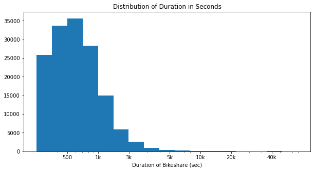

## Distribution of Member Age

The distribution of member_age appears to be skewed on the right, with the peek between 25 and 30. This means the members of the bike-sharing system are mostly youths. With very few senior citizens.

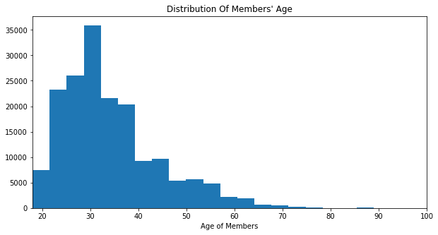

## Duration of Rides vs Members' Age

Although the average ride duration falls around 705 seconds, members who are between 20 to 45 years old tend to have rides with the most duration above average. This answers the question, does age affect the duration of rides?

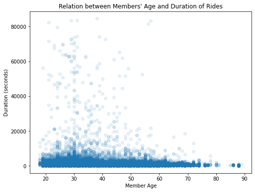

## Duration of Ride by Member Gender and User Type?

The customers who are of the 'Other' gender has more ride durations than customers who are of male and female gender.

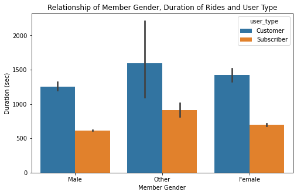